# BANA 7050: Assignment 2

Author

Ayush Paliwal

Published

February 9, 2023

```r
knitr::opts_chunk$set(fig.align = "center")

library(dplyr)
library(tidyr)
library(lubridate)
library(tsibble)
library(ggplot2)
library(kableExtra)
library(forecast)
library(tidyquant)
library(zoo)
library(patchwork)
library(feasts)
library(fable)
library(tseries)
```

```r
unemployment = readr::read_csv("UNRATENSA.csv")
unemployment = unemployment %>%
  mutate(Date = DATE, )

attach(unemployment)

unemployment = unemployment %>%
  mutate(Date = yearmonth(DATE), Unemp_Rate = UNRATENSA) %>%
  select(Date, Unemp_Rate) %>%
  as_tsibble(index = Date)

unemployment_test <- unemployment %>%
  filter(between(Date, as.Date('2019-01-01'), as.Date('2019-06-01'))) %>%
  mutate(Date = yearmonth(Date)) %>%
  as_tsibble()

unemployment = unemployment %>%
  filter(between(Date, as.Date('2010-01-01'), as.Date('2018-12-01')))
```

## Section 1:

#### Rolling mean to detect if time series is **Mean Stationary**:

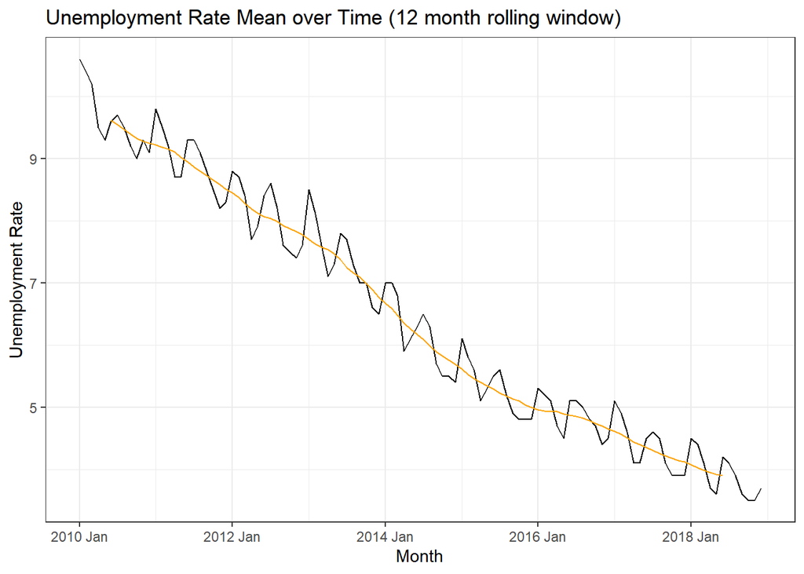

```r
k = 12
unemployment_roll <- unemployment %>%
  mutate(
    unemp_mean = zoo::rollmean(
      Unemp_Rate,
      k = k,
      fill = NA),
    Unemp_sd = zoo::rollapply(
      Unemp_Rate,
      FUN = sd,
      width = k,
      fill = NA)
  )

unemployment_roll_mean <- unemployment_roll %>%
  ggplot() +
    geom_line(aes(Date, Unemp_Rate)) +
  geom_line(aes(Date, unemp_mean),color='orange') +
  theme_bw() +
  ggtitle("Unemployment Rate Mean over Time (12 month rolling window)") +
  ylab("Unemployment Rate") +
  xlab("Month")

unemployment_roll_mean
```

1. We can clearly observe that the rolling mean follows an almost linearly decreasing trend
2. Since the rolling mean of the series is changing with time, the time-series is **NOT Mean Stationary**

#### Rolling standard deviation to detect if time series is **Variance Stationary**:

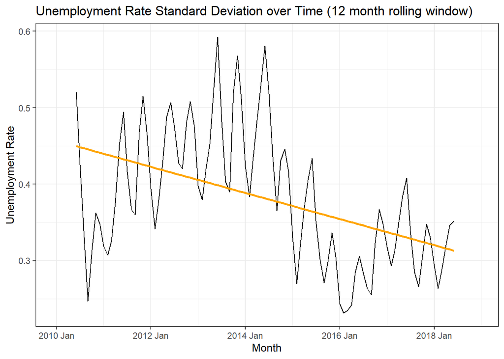

```r
unemployment_roll_sd <- unemployment_roll %>%
  ggplot() +
  geom_line(aes(Date, Unemp_sd)) +
  geom_smooth(aes(Date, Unemp_sd),method='lm',se=F,color='orange')+
  theme_bw() +
  ggtitle("Unemployment Rate Standard Deviation over Time (12 month rolling window)") +
  ylab("Unemployment Rate") +
  xlab("Month")

unemployment_roll_sd
```

1. Although the rolling standard deviation is varying with time, its **magnitude of variation is very small**
2. Since the rolling standard deviation is not changing significantly with time, the time-series is **Variance Stationary**
3. Hence there is no need to perform Natural Log or Box-Cox transformation

#### Seasonal differencing to remove the seasonal effect:

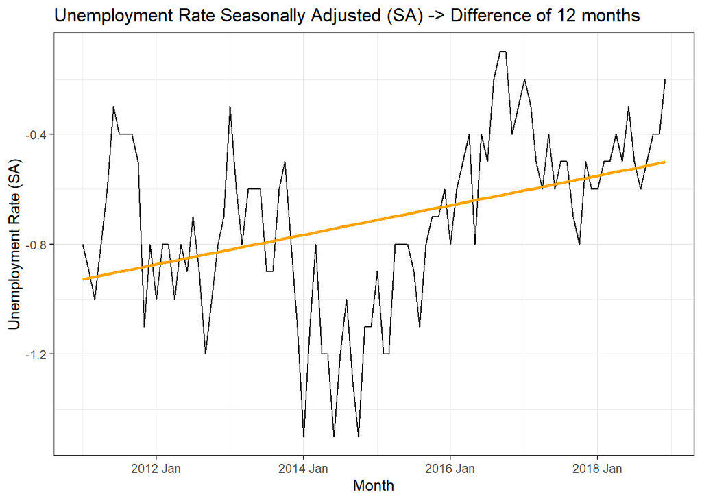

```r
unemployment_diff <- unemployment %>%
  mutate(Unemp_Rate_seasonal_diff = Unemp_Rate - lag(Unemp_Rate, 12)) %>%
  drop_na() %>%
  as_tsibble(index=Date)

unemployment_diff %>%
  ggplot() +
  geom_line(aes(Date, Unemp_Rate_seasonal_diff)) +
  geom_smooth(aes(Date, Unemp_Rate_seasonal_diff),method='lm',se=F,color='orange')+
  theme_bw() +
  ggtitle("Unemployment Rate Seasonally Adjusted (SA) -> Difference of 12 months") +
  ylab("Unemployment Rate (SA)") +
  xlab("Month")+
  theme_bw()
```

#### Seasonality testing through KPSS & ADF:

```r
unemployment_diff %>%
features(Unemp_Rate_seasonal_diff, unitroot_kpss)
```

```
# A tibble: 1 × 2
  kpss_stat kpss_pvalue
      <dbl>       <dbl>
1     0.786        0.01
```

```r
adf.test(unemployment_diff$Unemp_Rate_seasonal_diff)
```

```
    Augmented Dickey-Fuller Test

data:  unemployment_diff$Unemp_Rate_seasonal_diff
Dickey-Fuller = -1.7327, Lag order = 4, p-value = 0.6869
alternative hypothesis: stationary
```

1. Both the tests suggest the time series is **Non Stationary**

#### Seasonality testing through KPSS & ADF after 1st Order Integration:

```r
unemployment_diff <- unemployment_diff %>%
  mutate(Unemp_Rate_seasonal_diff_I1 = Unemp_Rate_seasonal_diff - lag(Unemp_Rate_seasonal_diff)) %>%
  drop_na() %>%
  as_tsibble(index=Date)

unemployment_diff %>%
features(Unemp_Rate_seasonal_diff_I1, unitroot_kpss)
```

```
# A tibble: 1 × 2
  kpss_stat kpss_pvalue
      <dbl>       <dbl>
1    0.0650         0.1
```

```r
adf.test(unemployment_diff$Unemp_Rate_seasonal_diff_I1)
```

```
    Augmented Dickey-Fuller Test

data:  unemployment_diff$Unemp_Rate_seasonal_diff_I1
Dickey-Fuller = -5.2097, Lag order = 4, p-value = 0.01
alternative hypothesis: stationary
```

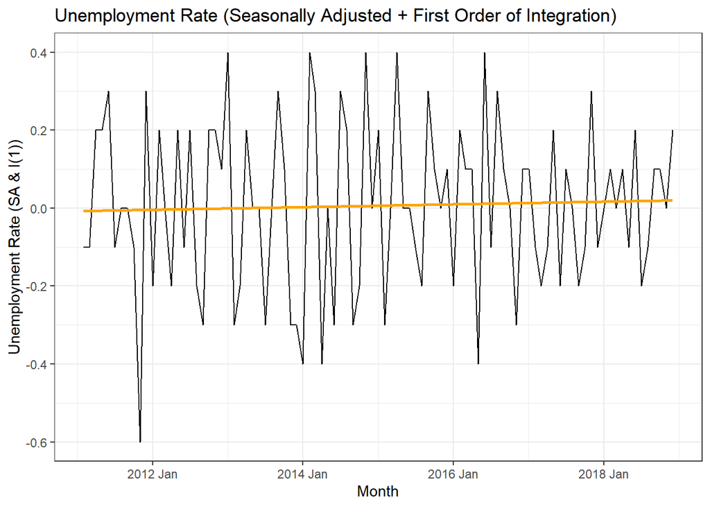

```r
unemployment_diff %>%
  ggplot() +
  geom_line(aes(Date, Unemp_Rate_seasonal_diff_I1)) +
  geom_smooth(aes(Date, Unemp_Rate_seasonal_diff_I1),method='lm',se=F,color='orange')+
  ggtitle("Unemployment Rate (Seasonally Adjusted + First Order of Integration)") +
  ylab("Unemployment Rate (SA & I(1))") +
  xlab("Month")+
  theme_bw()
```

1. We get a stationary time series on taking the first difference of Seasonally Adjusted time series
2. Both, ADF and KPSS test suggest the time series is now **Stationary**

## Section 2:

#### ACF and PACF plots for the transformed series:

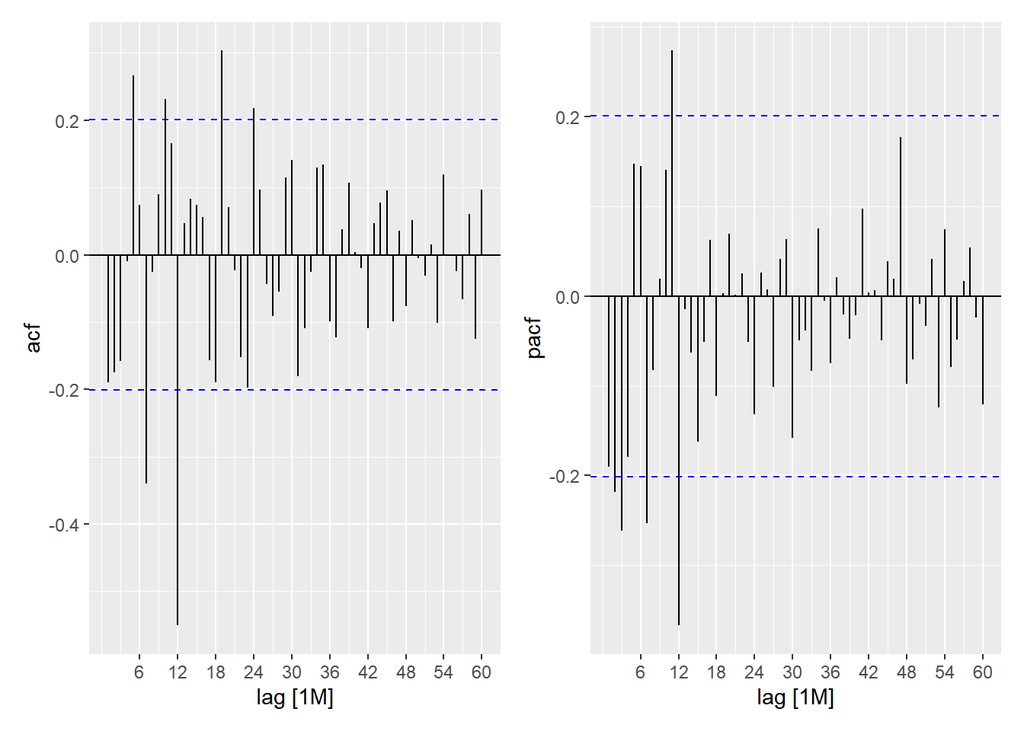

```r
acf = unemployment_diff %>%
  ACF(Unemp_Rate_seasonal_diff_I1,lag_max=60) %>%
  autoplot()

pacf =  unemployment_diff %>%
  fill_gaps() %>%
  PACF(Unemp_Rate_seasonal_diff_I1,lag_max=60) %>%
  autoplot()

acf + pacf
```

1. Based on the ACF and PACF analysis, this process seems to be a combination of Moving Average and Auto Regressive Process but it is unclear
2. I suspect the order of the time-series (p, d, q) to be (3,1,1)
3. It seems the time series still contains a significant seasonality component
4. Seasonal ARIMA effects (P, D, Q) could be (0,1,1) based on the spikes at lag of multiples of 12

## Section 3:

#### Build and Comapre models based on AIC and BIC:

```r
models_bic = unemployment %>%
  model(
    mod1 = ARIMA(Unemp_Rate~PDQ(0,1,0)+pdq(0,1,1)),
    mod2 = ARIMA(Unemp_Rate~PDQ(0,1,1)+pdq(0,1,1)),
    mod3 = ARIMA(Unemp_Rate~PDQ(1,1,0)+pdq(0,1,1)),
    mod4 = ARIMA(Unemp_Rate~PDQ(2,1,0)+pdq(0,1,1)),
    mod5 = ARIMA(Unemp_Rate~PDQ(2,1,1)+pdq(0,1,1)),
    mod6 = ARIMA(Unemp_Rate~PDQ(0,1,2)+pdq(0,1,1)),
    mod7 = ARIMA(Unemp_Rate~PDQ(1,1,2)+pdq(0,1,1)),
    mod8 = ARIMA(Unemp_Rate~PDQ(1,1,1)+pdq(0,1,1)),
    mod9 = ARIMA(Unemp_Rate~PDQ(2,1,2)+pdq(0,1,1)),
  )

models_bic %>%
  glance() %>%
  arrange(BIC)
```

```
# A tibble: 9 × 8
  .model sigma2 log_lik   AIC  AICc   BIC ar_roots   ma_roots
  <chr>   <dbl>   <dbl> <dbl> <dbl> <dbl> <list>     <list>
1 mod2   0.0204    38.0 -69.9 -69.7 -62.3 <cpl [0]>  <cpl [13]>
2 mod8   0.0198    38.5 -69.1 -68.6 -58.9 <cpl [12]> <cpl [13]>
3 mod6   0.0199    38.4 -68.8 -68.4 -58.6 <cpl [0]>  <cpl [25]>
4 mod5   0.0204    39.4 -68.8 -68.1 -56.0 <cpl [24]> <cpl [13]>
5 mod7   0.0198    39.2 -68.4 -67.7 -55.6 <cpl [12]> <cpl [25]>
6 mod9   0.0204    39.5 -67.1 -66.1 -51.8 <cpl [24]> <cpl [25]>
7 mod3   0.0286    32.5 -59.0 -58.7 -51.3 <cpl [12]> <cpl [1]>
8 mod4   0.0274    34.3 -60.6 -60.1 -50.3 <cpl [24]> <cpl [1]>
9 mod1   0.0436    14.4 -24.8 -24.7 -19.7 <cpl [0]>  <cpl [1]>
```

1. Among all the models configurations we tried, **(0,1,1) (0,1,1)** is the **most optimum** based on AIC and BIC scores
2. Our **best guess** based on ACF and PACF analysis was **(3,1,1) (0,1,1)**

#### Predict on the in-smaple data and plot:

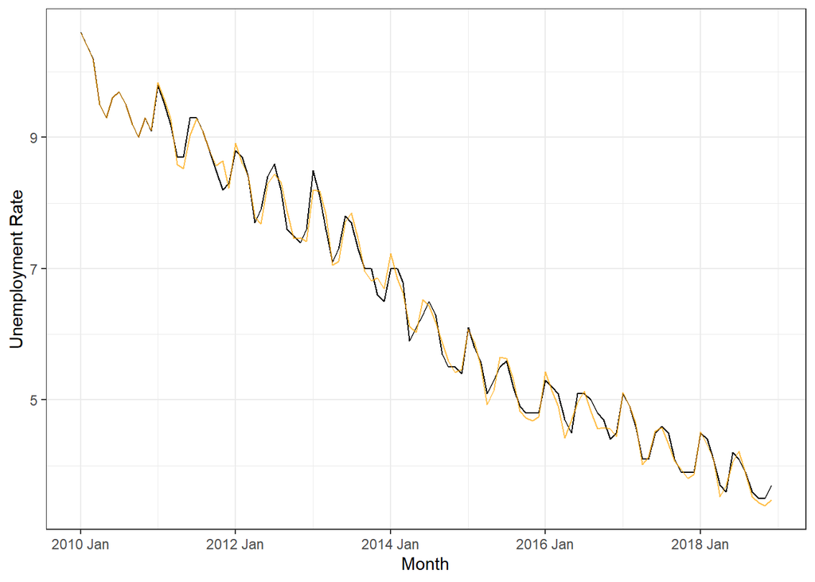

```r
best_mod = unemployment %>%
  model(
    ARIMA(Unemp_Rate~PDQ(0,1,1)+pdq(0,1,1), stepwise=FALSE, approximation=FALSE)
  )

# Get fitted values
fitted = best_mod %>%
  augment() %>%
  .$.fitted

ggplot() +
  geom_line(aes(unemployment$Date, unemployment$Unemp_Rate)) +
  geom_line(aes(unemployment$Date, fitted), color = "orange", alpha = 0.7) +
  theme_bw() +
  xlab("Month") +
  ylab("Unemployment Rate")
```

1. The in-sample forecast values tend to closely follow the trend in the data

## Section 4:

#### Box-Ljung test for residual autocorrelation:

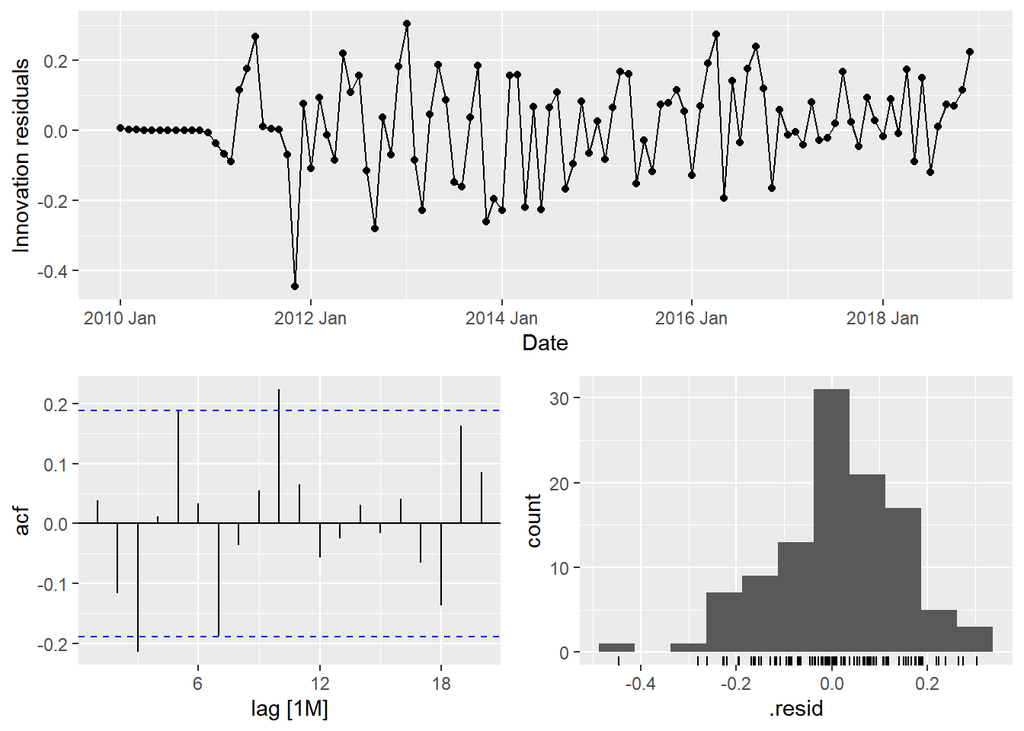

```r
best_mod %>%
  gg_tsresiduals()
```

```r
best_mod %>%
  augment() %>%
  features(.innov, ljung_box, lag = 12, dof = 2)
```

```
# A tibble: 1 × 3
  .model                                                         lb_stat lb_pv…¹
  <chr>                                                            <dbl>   <dbl>
1 "ARIMA(Unemp_Rate ~ PDQ(0, 1, 1) + pdq(0, 1, 1), stepwise = F…    22.8  0.0117
# … with abbreviated variable name ¹lb_pvalue
```

1. We observe significant autocorrelation in residuals for several lag values based on the Box-Ljung test and ACF plots
2. Hence the residuals cannot be considered as white noise

#### Finding a better model:

```r
best_unrate_mod = unemployment %>%
  model(ARIMA(approximation=F,stepwise=F))

best_unrate_mod %>%
  report()
```

```
Series: Unemp_Rate
Model: ARIMA(3,1,0)(2,1,0)[12]

Coefficients:
          ar1      ar2      ar3     sar1     sar2
      -0.2585  -0.1888  -0.2380  -0.7179  -0.2190
s.e.   0.1006   0.1025   0.0995   0.1092   0.1133

sigma^2 estimated as 0.02654:  log likelihood=36.9
AIC=-61.81   AICc=-60.85   BIC=-46.48
```

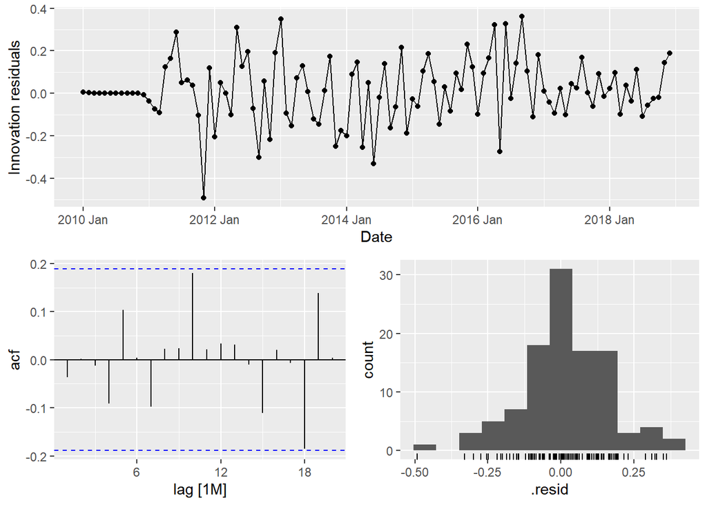

```r
best_unrate_mod %>%
  gg_tsresiduals()
```

```r
best_unrate_mod %>%
  augment() %>%
  features(.innov, ljung_box, lag = 12, dof = 5)
```

```
# A tibble: 1 × 3
  .model                                 lb_stat lb_pvalue
  <chr>                                    <dbl>     <dbl>
1 ARIMA(approximation = F, stepwise = F)    7.76     0.354
```

1. The p-values from the Box-Ljung test are now greater than 0.05
2. The ACF plot does not show significant autocorrelation in residuals
3. Hence the residuals can be considered as White Noise
4. Our best model is **ARIMA(3,1,0)(2,1,0)[12]**

#### Generating Forecast:

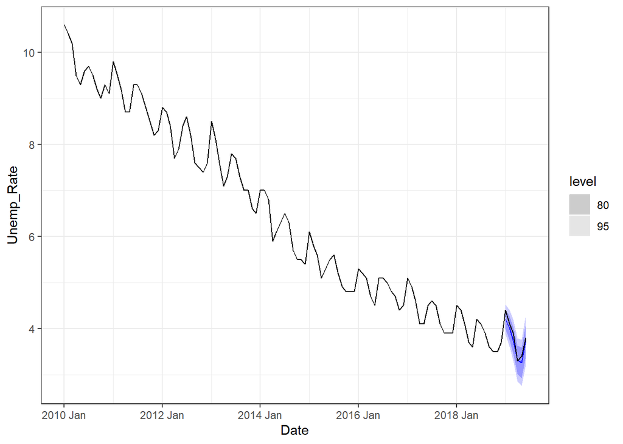

```r
best_unrate_mod %>%
  forecast(h=6) %>%
  autoplot(
    unemployment %>%
      bind_rows(unemployment_test)
  )+
  theme_bw()
```

1. Our forecast values are very close to actual values and seem reasonable